```r
ma12 <- atheism %>%
  filter(nationality == 'Macedonia' & year == '2012')

ma12 %>%
  group_by(response) %>%
  summarize(num = n()) %>%
  mutate(denom = num / sum(num))
```

```
## # A tibble: 2 x 3
##   response      num   denom
##   <fct>       <int>   <dbl>
## 1 atheist        12 0.00993
## 2 non-atheist  1197 0.990
```

```r
inference(ma12$response, est = "proportion", type = "ci", method = "theoretical",
          success = "atheist")
```

```
## Single proportion -- success: atheist
## Summary statistics:
```

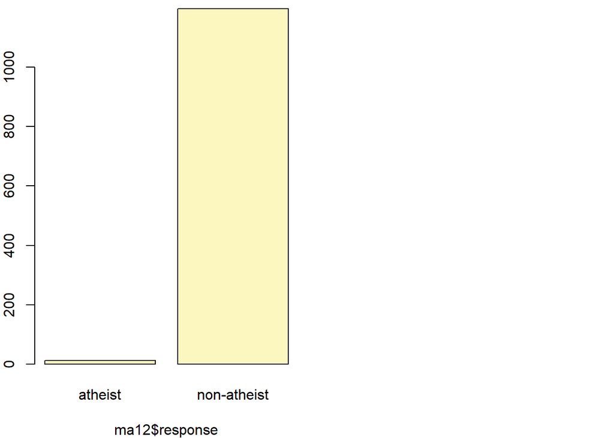

```
## p_hat = 0.0099 ;  n = 1209
## Check conditions: number of successes = 12 ; number of failures = 1197
## Standard error = 0.0029
## 95 % Confidence interval = ( 0.0043 , 0.0155 )
```

1. Data is collected independently. This is a reasonable assumption
2. Less than 10% of the population. This is clearly true.
3. Expecting at least 10 positive and negative responses. This is clearly true.

The conditions for inference are met.

It can be stated with 95% confidence that the proportion of people from Argentina who are atheists is between 0.0547 and 0.0866.

It can be stated with 95% confidence that the proportion of people from Macedonia who are atheists is between 0.0043 and 0.0155.

#8: Describe the relationship between p and me.

As the probability of success tends towards 0.5, the margin of error increases.

#9: Describe the sampling distribution of sample proportions at n=1040 and p=0.1. Be sure to note the center, spread, and shape.

```r
mean(p_hats)
```

```
## [1] 0.1000546
```

```r
sd(p_hats)
```

```
## [1] 0.00931331
```

```r
max(p_hats) - min(p_hats)
```

```
## [1] 0.07019231
```

The sampling distribution is nearly normal. The center is $\approx0.1$ with a standard deviation of $\approx0.009$. The spread is $0.07$.

#10: Repeat the above simulation three more times but with modified sample sizes and proportions: for n=400 and p=0.1, n=1040 and p=0.02, and n=400 and p=0.02. Plot all four histograms together by running the par(mfrow = c(2, 2)) command before creating the histograms. You may need to expand the plot window to accommodate the larger two-by-two plot. Describe the three new sampling distributions. Based on these limited plots, how does n appear to affect the distribution of p^? How does p affect the sampling distribution?

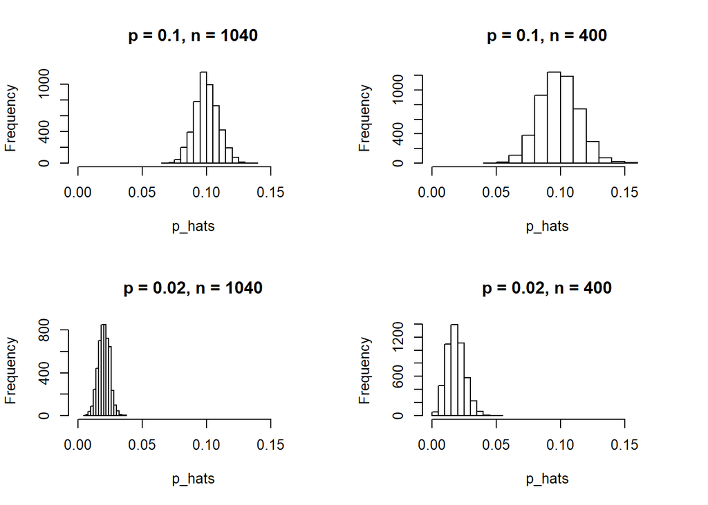

```r
par(mfrow = c(2, 2))

p <- 0.1
n <- 1040
p_hats <- rep(0, 5000)

for(i in 1:5000){
  samp <- sample(c("atheist", "non_atheist"), n, replace = TRUE, prob = c(p, 1-p))
  p_hats[i] <- sum(samp == "atheist")/n
}

hist(p_hats, main = "p = 0.1, n = 1040", xlim = c(0, 0.18))

p <- 0.1
n <- 400
p_hats <- rep(0, 5000)

for(i in 1:5000){
  samp <- sample(c("atheist", "non_atheist"), n, replace = TRUE, prob = c(p, 1-p))
  p_hats[i] <- sum(samp == "atheist")/n
}

hist(p_hats, main = "p = 0.1, n = 400", xlim = c(0, 0.18))

p <- 0.02
n <- 1040
p_hats <- rep(0, 5000)

for(i in 1:5000){
  samp <- sample(c("atheist", "non_atheist"), n, replace = TRUE, prob = c(p, 1-p))
  p_hats[i] <- sum(samp == "atheist")/n
}

hist(p_hats, main = "p = 0.02, n = 1040", xlim = c(0, 0.18))

p <- 0.02
n <- 400
p_hats <- rep(0, 5000)

for(i in 1:5000){
  samp <- sample(c("atheist", "non_atheist"), n, replace = TRUE, prob = c(p, 1-p))
  p_hats[i] <- sum(samp == "atheist")/n
}

hist(p_hats, main = "p = 0.02, n = 400", xlim = c(0, 0.18))
```

The value of p affects the center of the sampling distribution, that is, the value of $\hat{p}$ The value of n affects the spread of the sampling distribution. The larger n is, the smaller the spread.

#11: If you refer to Table 6, you’ll find that Australia has a sample proportion of 0.1 on a sample size of 1040, and that Ecuador has a sample proportion of 0.02 on 400 subjects. Let’s suppose for this exercise that these point estimates are actually the truth. Then given the shape of their respective sampling distributions, do you think it is sensible to proceed with inference and report margin of errors, as the reports does?

### On Your Own

#1: Answer the following two questions using the inference function. As always, write out the hypotheses for any tests you conduct and outline the status of the conditions for inference.

a: Is there convincing evidence that Spain has seen a change in its atheism index between 2005 and 2012? Hint: Create a new data set for respondents from Spain. Form confidence intervals for the true proportion of athiests in both years, and determine whether they overlap.

```r
sp <- atheism %>%
  filter(nationality == 'Spain')

sp05 <- sp %>%
  filter(year == '2005')

inference(sp05$response, est = "proportion", type = "ci", method = "theoretical",
        success = "atheist")
```

```
## Single proportion -- success: atheist
## Summary statistics:
```

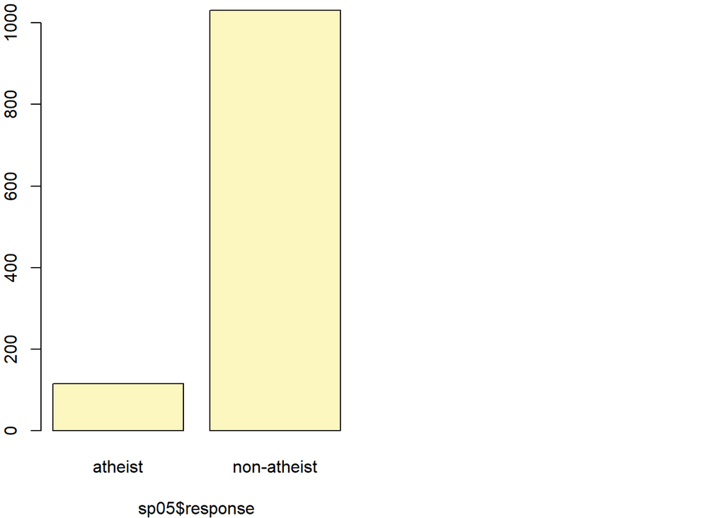

```
## p_hat = 0.1003 ;  n = 1146
## Check conditions: number of successes = 115 ; number of failures = 1031
## Standard error = 0.0089
## 95 % Confidence interval = ( 0.083 , 0.1177 )
```

```r
sp12 <- sp %>%
  filter(year == '2012')

inference(sp12$response, est = "proportion", type = "ci", method = "theoretical",
          success = "atheist")
```

```
## Single proportion -- success: atheist
## Summary statistics:
```

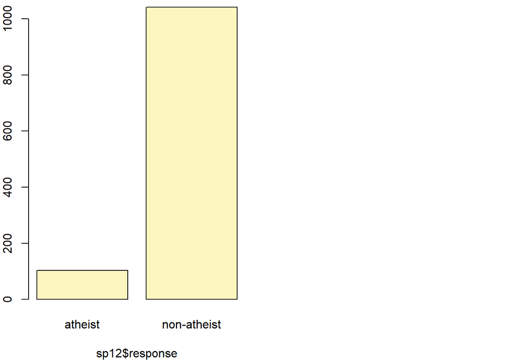

```
## p_hat = 0.09 ;  n = 1145
## Check conditions: number of successes = 103 ; number of failures = 1042
## Standard error = 0.0085
## 95 % Confidence interval = ( 0.0734 , 0.1065 )
```

$H_{0}$: The levels of atheism in Spain between 2005 and 2012 remains the same. $H_{a}$: The levels of atheism in Spain have changed.

1. Data is collected independently.
2. Less than 10% of the population.
3. Expecting at least 10 positive and negative responses.

The conditions for inferences have been met.

As the confidence intervals overlap, there is no evidence to suggest a chance in atheism levels. We fail to reject the null hypothesis.

b: Is there convincing evidence that the United States has seen a change in its atheism index between 2005 and 2012?

```r
usa <- atheism %>%
  filter(nationality == 'Spain')

usa05 <- usa %>%
  filter(year == '2005')

inference(usa05$response, est = "proportion", type = "ci", method = "theoretical",
          success = "atheist")
```

```
## Single proportion -- success: atheist
## Summary statistics:
```

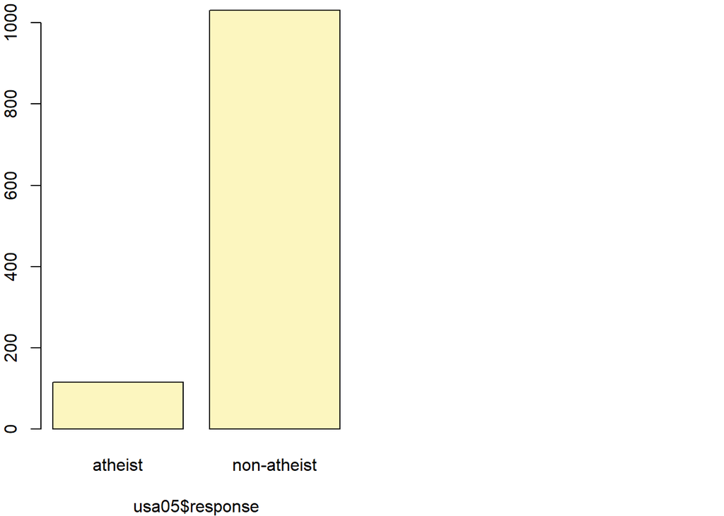

```
## p_hat = 0.1003 ;  n = 1146
## Check conditions: number of successes = 115 ; number of failures = 1031
## Standard error = 0.0089
## 95 % Confidence interval = ( 0.083 , 0.1177 )
```

```r
usa12 <- usa %>%
  filter(year == '2012')

inference(usa12$response, est = "proportion", type = "ci", method = "theoretical",
          success = "atheist")
```

```
## Single proportion -- success: atheist
## Summary statistics:
```

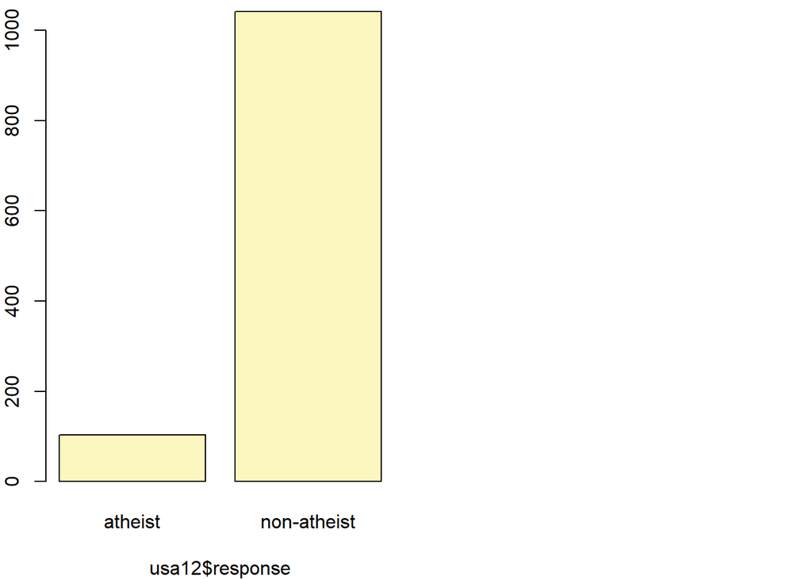

```
## p_hat = 0.09 ;  n = 1145
## Check conditions: number of successes = 103 ; number of failures = 1042
## Standard error = 0.0085
## 95 % Confidence interval = ( 0.0734 , 0.1065 )
```

1. Data is collected independently.
2. Less than 10% of the population.
3. Expecting at least 10 positive and negative responses.

The conditions for inferences have been met.

#2: If in fact there has been no change in the atheism index in the countries listed in Table 4, in how many of those countries would you expect to detect a change (at a significance level of 0.05) simply by chance? Hint: Look in the textbook index under Type 1 error.

Considering there are 39 countries we would expect $39\times.05=1.95$ or about 2 false positives.

#3: Suppose you’re hired by the local government to estimate the proportion of residents that attend a religious service on a weekly basis. According to the guidelines, the estimate must have a margin of error no greater than 1% with 95% confidence. You have no idea what to expect for p. How many people would you have to sample to ensure that you are within the guidelines?

$$1.96\times\sqrt{\frac{0.5\times(1-0.5)}{n}}<0.01, n=9604$$
Using $p=0.5$ as this provides the largest possible margin of error, we would need to ask 9604 people in order to be able to create a 95% confidence interval with less than a 1% margin of error.